# Bike Sharing Demand

## Introduction

We have to predict the total count of bikes rented during each hour covered by the test set, using only information available prior to the rental period.

```r
require(plyr)
detach(package:plyr)
library(tidyverse)
library(lubridate)
library(broom)
library(caret)
library(scales)
library(ggcorrplot)
library(parallel)
library(doParallel)
```

```r
train.data <- tbl_df(read.csv('./Input/train.csv', stringsAsFactors = F))
test.data <- tbl_df(read.csv('./Input/test.csv', stringsAsFactors = F))
```

## Data Pre-processing, Cleaning & Feature Extraction

Replacing season codes with corresponding values.

```r
season.list <- c('spring', 'summer', 'fall', 'winter')
replace_season <- function(df){
    df[['season']] <- plyr::mapvalues(df[['season']],
                                  from = c(1, 2, 3, 4),
                                  to = season.list)
    return(df)
}
train.data <- replace_season(train.data)
```

Replacing wweather codes as follows:  
weather 1: clear_partly_cloudy weather 2: mist_cloudy weather 3: light_snow_rain_thunderstorm weather 4: heavy_snow_rain_ice_fog_thunderstorm

```r
weather.list <- c('clear_partly_cloudy', 'mist_cloudy',
                  'light_snow_rain_thunderstorm',
                  'heavy_snow_rain_ice_fog_thunderstorm')
replace_weather <- function(df){
    df[['weather']] <- plyr::mapvalues(df[['weather']],
                                  from = c(1, 2, 3, 4),
                                  to = weather.list)

    return(df)
}
train.data <- replace_weather(train.data)
```

Splitting datetime into year, month, day_num, day_name, hour

```r
train.data <- train.data %>%
    mutate(date.year = 0, date.month = '', month.day = 0,
           week.day = '', day.hour = 0)
split_date <- function(df){
    df[['date.year']] = year(df[['datetime']])
    df[['date.month']] = month(df[['datetime']], label = T)
    df[['month.day']] = day(df[['datetime']])
    df[['week.day']] = wday(df[['datetime']], label = T)
    df[['day.hour']] = hour(df[['datetime']])

    return(df)
}
train.data <- split_date(train.data)
```

Adding new column, temp.div <- temp / atemp

```r
train.data <- train.data %>%
    mutate(temp.div = temp / atemp)
```

Adding new column, day.type – working day, holiday or weekend

```r
train.data <- train.data %>%
    mutate(day.type = NA)
day_type <- function(df){
    df[['day.type']] <- ifelse(df[['holiday']] == 1, 'Holiday',
                               ifelse(df[['workingday']] == 1, 'Workingday',
                                      'Weekend'))
    return(df)
}
train.data <- day_type(train.data) %>% select(-holiday, -workingday)
```

Converting columns into factors

```r
train.data[c(2:3, 11:15, 17)] <-
    lapply(train.data[c(2:3, 11:15, 17)], factor)
```

We know a month has 31 days, so lets add the missing levels (20 to 31)

```r
addLevel <- function(x, newlevel = NULL){
    if(is.factor(x))
        return(factor(x, levels = c(levels(x), newlevel)))

    return(x)
}

train.data$month.day <- addLevel(train.data$month.day, newlevel = c(20:31))
```

Now lets check the data again

```r
summary(train.data)
```

```
   datetime            season                                     weather
 Length:10886       fall  :2733   clear_partly_cloudy                 :7192
 Class :character   spring:2686   heavy_snow_rain_ice_fog_thunderstorm:   1
 Mode  :character   summer:2733   light_snow_rain_thunderstorm        : 859
                    winter:2734   mist_cloudy                         :2834



      temp           atemp          humidity        windspeed
 Min.   : 0.82   Min.   : 0.76   Min.   :  0.00   Min.   : 0.000
 1st Qu.:13.94   1st Qu.:16.66   1st Qu.: 47.00   1st Qu.: 7.002
 Median :20.50   Median :24.24   Median : 62.00   Median :12.998
 Mean   :20.23   Mean   :23.66   Mean   : 61.89   Mean   :12.799
 3rd Qu.:26.24   3rd Qu.:31.06   3rd Qu.: 77.00   3rd Qu.:16.998
 Max.   :41.00   Max.   :45.45   Max.   :100.00   Max.   :56.997

     casual         registered        count       date.year     date.month
 Min.   :  0.00   Min.   :  0.0   Min.   :  1.0   2011:5422   May    : 912
 1st Qu.:  4.00   1st Qu.: 36.0   1st Qu.: 42.0   2012:5464   Jun    : 912
 Median : 17.00   Median :118.0   Median :145.0               Jul    : 912
 Mean   : 36.02   Mean   :155.6   Mean   :191.6               Aug    : 912
 3rd Qu.: 49.00   3rd Qu.:222.0   3rd Qu.:284.0               Dec    : 912
 Max.   :367.00   Max.   :886.0   Max.   :977.0               Oct    : 911
                                                              (Other):5415
   month.day     week.day       day.hour       temp.div            day.type
 1      : 575   Sun  :1579   12     : 456   Min.   :0.2706   Holiday   : 311
 5      : 575   Mon  :1551   13     : 456   1st Qu.:0.8119   Weekend   :3163
 9      : 575   Tues :1539   14     : 456   Median :0.8528   Workingday:7412
 17     : 575   Wed  :1551   15     : 456   Mean   :0.8496
 4      : 574   Thurs:1553   16     : 456   3rd Qu.:0.8762
 7      : 574   Fri  :1529   17     : 456   Max.   :2.9092
 (Other):7438   Sat  :1584   (Other):8150
```

## Data Exploration

First lets check the proportion of casual to registered users

```r
train.data %>% mutate(casual.count = sum(casual),
                      registered.count = sum(registered)) %>%
    select(casual.count, registered.count) %>%
    distinct() %>%
    gather(key = user.type, value = user.count,
           casual.count:registered.count) %>%
    mutate(user.prop = user.count / sum(user.count))
```

| user.type | user.count | user.prop |
| --- | --- | --- |
| casual.count | 392135 | 0.1880314 |
| registered.count | 1693341 | 0.8119686 |

```r
NA
```

### No. of Users by Season & Weather

Lets check the effect of seasons and weather on the users

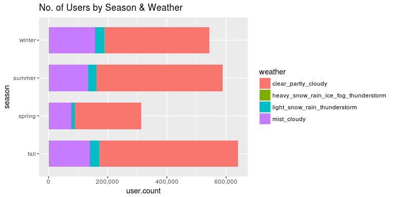

```r
train.data %>%
    select(season, weather, count) %>%
    group_by(season, weather) %>%
    mutate(user.count = sum(count)) %>%
    distinct(season, weather,user.count) %>%
    ggplot(mapping = aes(season, user.count, fill = weather)) +
    geom_bar(stat = 'identity', width = 0.7) +
    scale_y_continuous(labels = comma) +
    coord_flip() +
    ggtitle('No. of Users by Season & Weather')
```

It seems less people ride bicycles during Spring season than other seasons.

Most people ride during good weather (Clear, Partly Cloudy). Only the most dedicated ride in bad weather (Thunderstorm, Light snow or Rain).

### Usage pattern over Days of Week & Hours of Day

Lets check user count over days of week

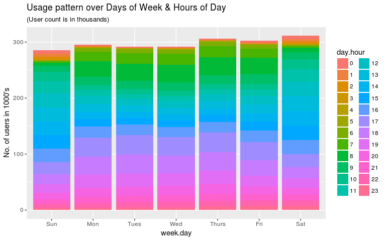

```r
train.data %>%
    select(week.day, day.hour, count) %>%
    group_by(week.day, day.hour) %>%
    mutate(user.count = sum(count)) %>%
    distinct(week.day, day.hour, user.count) %>%
    ggplot(mapping = aes(x = week.day, y = user.count/1000,
                         fill = day.hour)) +
    geom_bar(stat = 'identity') +
    ylab('No. of users in 1000\'s') +
    ggtitle(label = 'Usage pattern over Days of Week & Hours of Day',
            subtitle = '(User count is in thousands)')
```

The overall user count remains almost same for all 7 day of the week. But clear patterns can be seen for hourly usage on weekdays vs weekends.

On weekends the 11 AM to 5 PM time has most traffic.

### No. of Users based on Hour of Day over the Years

Lets check what time of the day most users ride.

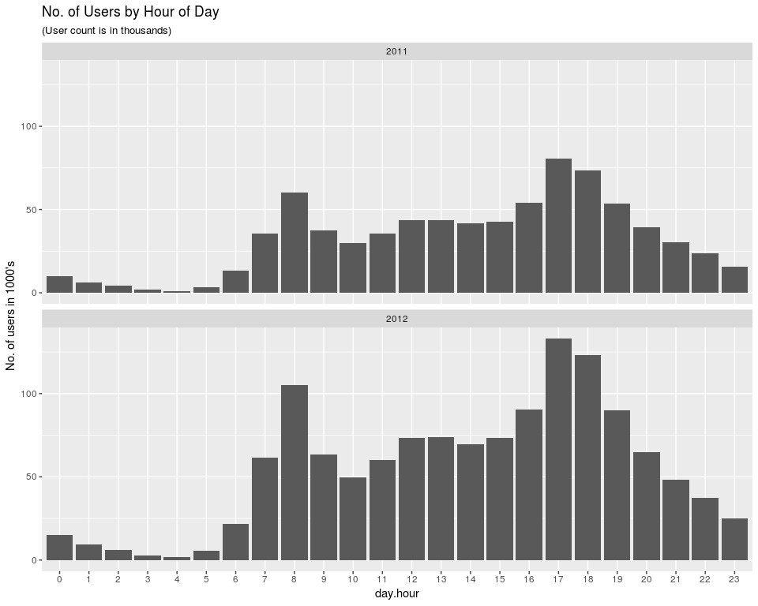

```r
train.data %>%
    select(day.hour, date.year, count) %>%
    group_by(day.hour, date.year) %>%
    mutate(user.count = sum(count)) %>%
    distinct(day.hour, date.year, user.count) %>%
    ggplot(mapping = aes(x = day.hour, y = user.count/1000)) +
    geom_bar(stat = 'identity') +
    facet_wrap(~ date.year, nrow = 2) +
    ylab('No. of users in 1000\'s') +
    ggtitle(label = 'No. of Users by Hour of Day',
            subtitle = '(User count is in thousands)')
```

As expected, most users ride between 6 AM to 11 PM. The bicycle use peaks at 8 AM and between 4 PM to 7 PM.

### Correlaton between features and User count

Lets see the correlation between numeric features and User count.

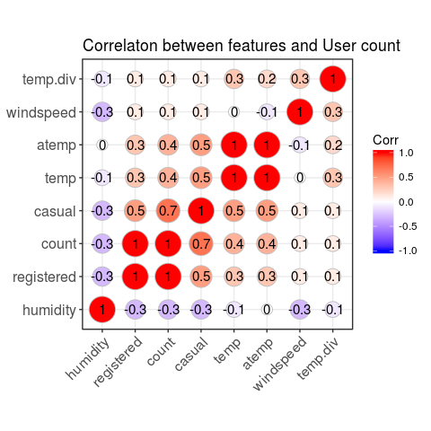

```r
train.data %>%
    select(temp, atemp, humidity, windspeed, temp.div,
           casual, registered, count) %>%
    distinct() %>% cor() %>% round(digits = 1) %>%
    ggcorrplot(method = 'circle',
               type = 'full', hc.order = T, lab = T, lab_size = 4,
               ggtheme = theme_bw,
               title = 'Correlaton between features and User count')
```

User Count seems to have positive correlation to Temperature and negative to humidity.

## Model Training, Prediction & Evaluation - 1

We will use Linear Model, Decision Tree(RPart) & Random Forest to train our models.

First we will Configure parallel processing

```r
ncluster <- makeCluster(detectCores() - 1)
registerDoParallel(ncluster)
```

Splitting training and testing datasets

```r
set.seed(777)
sample.train.data <- sample_n(train.data, size = 2000)

inTraining <- createDataPartition(y = sample.train.data$count,
                                  p = 0.75, list = F)
training <- sample.train.data[inTraining, ]
testing <- sample.train.data[-inTraining, ]
```

```r
# set.seed(777)
#
# inTraining <- createDataPartition(y = train.data$count,
#                                   p = 0.75, list = F)
# training <- train.data[inTraining, ]
# testing <- train.data[-inTraining, ]
```

Choosing Features to use in model

```r
feature.list <- c(2:3, 5:7, 11:17)
```

Setting train control and grid parameters

```r
tr.ctrl <- trainControl(method = 'repeatedcv', number = 5, repeats = 5,
                        verboseIter = T, allowParallel = T)
grid.rf <- expand.grid(.mtry = c(2, 4, 7, 14))
```

Training models

```r
set.seed(777)
fit.lm.casual <- train(x = training[feature.list], y = training$casual,
                       method = 'lm', metric = 'RMSE', trControl = tr.ctrl)
set.seed(777)
fit.lm.reg <- train(x = training[feature.list], y = training$registered,
                       method = 'lm', metric = 'RMSE', trControl = tr.ctrl)
set.seed(777)
fit.lm.count <- train(x = training[feature.list], y = training$count,
                       method = 'lm', metric = 'RMSE', trControl = tr.ctrl)
```

```r
set.seed(777)
fit.rpart.casual <- train(x = training[feature.list], y = training$casual,
                          method = 'rpart', metric = 'RMSE', trControl = tr.ctrl)
set.seed(777)
fit.rpart.reg <- train(x = training[feature.list], y = training$registered,
                          method = 'rpart', metric = 'RMSE', trControl = tr.ctrl)
set.seed(777)
fit.rpart.count <- train(x = training[feature.list], y = training$count,
                          method = 'rpart', metric = 'RMSE', trControl = tr.ctrl)
```

```r
set.seed(777)
fit.rf.casual <- train(x = training[feature.list], y = training$casual,
                method = 'rf', metric = 'RMSE', importance = T,
                trControl = tr.ctrl, tuneGrid = grid.rf)
set.seed(777)
fit.rf.reg <- train(x = training[feature.list], y = training$registered,
                method = 'rf', metric = 'RMSE', importance = T,
                trControl = tr.ctrl, tuneGrid = grid.rf)
set.seed(777)
fit.rf.count <- train(x = training[feature.list], y = training$count,
                method = 'rf', metric = 'RMSE', importance = T,
                trControl = tr.ctrl, tuneGrid = grid.rf)
```

Evaluating the models

```r
resamps <- resamples(list(LM.cas = fit.lm.casual,
                          LM.reg = fit.lm.reg,
                          LM.count = fit.lm.count,
                          RPART.cas = fit.rpart.casual,
                          RPART.reg = fit.rpart.reg,
                          RPART.count = fit.rpart.count,
                          RF.cas = fit.rf.casual,
                          RF.reg = fit.rf.reg,
                          RF.count = fit.rf.count))
summary(resamps)
```

```
Call:
summary.resamples(object = resamps)

Models: LM.cas, LM.reg, LM.count, RPART.cas, RPART.reg, RPART.count, RF.cas, RF.reg, RF.count
Number of resamples: 25

RMSE
                 Min.   1st Qu.    Median      Mean   3rd Qu.      Max. NA's
LM.cas       28.03257  30.94838  32.64376  32.34399  33.51193  35.71856    0
LM.reg       76.40389  81.66761  85.30556  85.52695  90.04644  96.35597    0
LM.count     94.82032  99.87543 101.46408 102.25598 104.37034 111.09550    0
RPART.cas    30.34399  32.98317  35.00789  34.93675  37.00279  39.81988    0
RPART.reg    90.90070 103.91419 115.60920 114.29497 119.33106 136.90922    0
RPART.count 114.51509 125.56325 127.53219 129.10008 134.37297 139.73612    0
RF.cas       17.83966  19.05852  20.94238  20.97832  22.87823  25.21915    0
RF.reg       50.61886  57.44869  58.89236  59.13576  62.07355  67.83083    0
RF.count     74.81238  77.89987  81.52985  81.29425  83.35522  91.34926    0

Rsquared
                 Min.   1st Qu.    Median      Mean   3rd Qu.      Max. NA's
LM.cas      0.5476284 0.5667586 0.5886763 0.5852901 0.5973778 0.6271085    0
LM.reg      0.5905012 0.6416841 0.6598615 0.6596910 0.6775800 0.7161088    0
LM.count    0.6282034 0.6477971 0.6621883 0.6648169 0.6817158 0.7160776    0
RPART.cas   0.4025193 0.4574303 0.5049726 0.5152306 0.5631220 0.6643993    0
RPART.reg   0.2731181 0.3104710 0.3472197 0.3861299 0.4586726 0.6228687    0
RPART.count 0.3700545 0.4291417 0.4541119 0.4642682 0.5076182 0.5752275    0
RF.cas      0.7715368 0.8327719 0.8514991 0.8472750 0.8701461 0.9057114    0
RF.reg      0.8021269 0.8352341 0.8452379 0.8472048 0.8632702 0.8893542    0
RF.count    0.7455366 0.7885782 0.8082772 0.8025852 0.8173866 0.8521945    0
```

Random Forest is clearly the best performer.

Variable Importance

```r
varImp(object = fit.rf.casual, scale = T)
```

```
rf variable importance

           Overall
day.hour   100.000
day.type    69.232
atemp       67.337
humidity    20.397
month.day   19.449
date.year   12.583
date.month   9.983
season       6.105
week.day     5.734
temp.div     3.113
weather      2.609
windspeed    0.000
```

```r
varImp(object = fit.rf.reg, scale = T)
```

```
rf variable importance

           Overall
day.hour   100.000
day.type    41.535
date.year   39.791
date.month  23.546
atemp       20.005
humidity    10.838
weather      7.418
season       5.961
week.day     5.902
windspeed    3.350
temp.div     1.504
month.day    0.000
```

```r
varImp(object = fit.rf.count, scale = T)
```

```
rf variable importance

           Overall
day.hour   100.000
date.year   37.234
atemp       36.906
day.type    23.406
date.month  16.932
humidity    14.206
week.day     6.168
season       6.057
temp.div     4.279
weather      3.046
windspeed    2.736
month.day    0.000
```

De-registering parallel processing cluster

```r
stopCluster(ncluster)
registerDoSEQ()
```

Lets run the model on our testing split.

```r
predict.rf.casual <- predict(fit.rf.casual, newdata = testing[feature.list])
predict.rf.reg <- predict(fit.rf.reg, newdata = testing[feature.list])
predict.rf.count <- predict(fit.rf.count, newdata = testing[feature.list])
predict.rf.count.add <- predict.rf.casual + predict.rf.reg
```

Lets evaluate our model

```r
RMSE(pred = predict.rf.count, obs = testing$count)
```

```
[1] 83.96497
```

```r
RMSE(pred = predict.rf.count.add, obs = testing$count)
```

```
[1] 75.08954
```

## Model Training, Prediction & Evaluation - 2

This time we will remove Features having variable importance less than 5% for each model and see if it improves our models.

First we will Configure parallel processing

```r
ncluster <- makeCluster(detectCores() - 1)
registerDoParallel(ncluster)
```

Splitting training and testing datasets

```r
set.seed(777)
sample.train.data <- sample_n(train.data, size = 2000)

inTraining <- createDataPartition(y = sample.train.data$count,
                                  p = 0.75, list = F)
training <- sample.train.data[inTraining, ]
testing <- sample.train.data[-inTraining, ]
```

```r
# set.seed(777)
#
# inTraining <- createDataPartition(y = train.data$count,
#                                   p = 0.75, list = F)
# training <- train.data[inTraining, ]
# testing <- train.data[-inTraining, ]
```

Choosing Features to use in model

```r
feature.list.casual2 <- c(2, 5:6, 11:15, 17)
feature.list.reg2 <- c(2:3, 5:6, 11:12, 14:15, 17)
feature.list.count2 <- c(2, 5:6, 11:12, 14:15, 17)
```

Setting train control and grid parameters

```r
tr.ctrl <- trainControl(method = 'repeatedcv', number = 5, repeats = 5,
                        verboseIter = T, allowParallel = T)
grid.rf <- expand.grid(.mtry = c(2, 4, 7, 14))
```

Training model

```r
set.seed(777)
fit.rf.casual2 <- train(x = training[feature.list.casual2], y = training$casual,
                method = 'rf', metric = 'RMSE', importance = T,
                trControl = tr.ctrl, tuneGrid = grid.rf)
set.seed(777)
fit.rf.reg2 <- train(x = training[feature.list.reg2], y = training$registered,
                method = 'rf', metric = 'RMSE', importance = T,
                trControl = tr.ctrl, tuneGrid = grid.rf)
set.seed(777)
fit.rf.count2 <- train(x = training[feature.list.count2], y = training$count,
                method = 'rf', metric = 'RMSE', importance = T,
                trControl = tr.ctrl, tuneGrid = grid.rf)
```

Evaluating the model

```r
resamps <- resamples(list(RF.Casual1 = fit.rf.casual,
                          RF.Casual2 = fit.rf.casual2,
                          RF.Reg1 = fit.rf.reg,
                          RF.Reg2 = fit.rf.reg2,
                          RF.Count = fit.rf.count,
                          RF.Count2 = fit.rf.count2))
summary(resamps)
```

```
Call:
summary.resamples(object = resamps)

Models: RF.Casual1, RF.Casual2, RF.Reg1, RF.Reg2, RF.Count, RF.Count2
Number of resamples: 25

RMSE
               Min.  1st Qu.   Median     Mean  3rd Qu.     Max. NA's
RF.Casual1 17.83966 19.05852 20.94238 20.97832 22.87823 25.21915    0
RF.Casual2 17.53165 19.23553 20.84968 20.98271 22.59774 24.72631    0
RF.Reg1    50.61886 57.44869 58.89236 59.13576 62.07355 67.83083    0
RF.Reg2    38.92506 44.72940 45.77944 46.32833 48.75057 54.41887    0
RF.Count   74.81238 77.89987 81.52985 81.29425 83.35522 91.34926    0
RF.Count2  56.27755 59.78211 63.19629 63.26437 67.21416 70.35373    0

Rsquared
                Min.   1st Qu.    Median      Mean   3rd Qu.      Max. NA's
RF.Casual1 0.7715368 0.8327719 0.8514991 0.8472750 0.8701461 0.9057114    0
RF.Casual2 0.7536578 0.8234560 0.8442942 0.8415341 0.8672722 0.8992189    0
RF.Reg1    0.8021269 0.8352341 0.8452379 0.8472048 0.8632702 0.8893542    0
RF.Reg2    0.8731196 0.8914021 0.9054424 0.9028228 0.9130406 0.9261161    0
RF.Count   0.7455366 0.7885782 0.8082772 0.8025852 0.8173866 0.8521945    0
RF.Count2  0.8459996 0.8624403 0.8748065 0.8746036 0.8885657 0.9070480    0
```

Variable Importance

```r
varImp(object = fit.rf.casual2, scale = T)
```

```
rf variable importance

           Overall
day.hour   100.000
day.type    68.211
atemp       65.376
humidity    17.913
month.day   15.127
date.year    8.827
date.month   6.978
season       2.157
week.day     0.000
```

```r
varImp(object = fit.rf.reg2, scale = T)
```

```
rf variable importance

           Overall
day.hour   100.000
date.year   48.679
day.type    33.295
date.month  19.074
atemp       13.015
humidity     4.956
season       3.489
weather      2.145
week.day     0.000
```

```r
varImp(object = fit.rf.count2, scale = T)
```

```
rf variable importance

           Overall
day.hour   100.000
date.year   34.340
atemp       27.232
day.type    24.959
date.month  10.785
humidity     9.924
week.day     0.658
season       0.000
```

De-registering parallel processing cluster

```r
stopCluster(ncluster)
registerDoSEQ()
```

Lets run the model on our testing split.

```r
predict.rf.casual2 <- predict(fit.rf.casual2,
                              newdata = testing[feature.list.casual2])
predict.rf.reg2 <- predict(fit.rf.reg2,
                           newdata = testing[feature.list.reg2])
predict.rf.count2 <- predict(fit.rf.count2,
                             newdata = testing[feature.list.count2])
predict.rf.count.add2 <- predict.rf.casual2 + predict.rf.reg2
```

Lets evaluate our model

```r
RMSE(pred = predict.rf.count2, obs = testing$count)
```

```
[1] 64.99861
```

```r
RMSE(pred = predict.rf.count.add2, obs = testing$count)
```

```
[1] 60.5439
```

## Model Training, Prediction & Evaluation - 3

First we will Configure parallel processing.

```r
# ncluster <- makeCluster(detectCores() - 1)
# registerDoParallel(ncluster)
```

Splitting training and testing datasets

```r
# set.seed(777)
#
# sample.train.data <- sample_n(train.data, size = 2000)
#
# inTraining <- createDataPartition(y = sample.train.data$count,
#                                   p = 0.75, list = F)
# training <- sample.train.data[inTraining, ]
# testing <- sample.train.data[-inTraining, ]
```

```r
# set.seed(777)
#
# inTraining <- createDataPartition(y = train.data$count,
#                                   p = 0.75, list = F)
# training <- train.data[inTraining, ]
# testing <- train.data[-inTraining, ]
```

Choosing Features to use in model

```r
# feature.list.casual3 <- c(2, 5:6, 11:15, 17)
# feature.list.reg3 <- c(2:3, 5:6, 11:12, 14:15, 17)
# feature.list.count3 <- c(2, 5:6, 11:12, 14:15, 17)
```

Setting train control and grid parameters

```r
# tr.ctrl <- trainControl(method = 'repeatedcv', number = 10, repeats = 10,
#                         verboseIter = T, allowParallel = T)
#
# grid.rf <- expand.grid(.mtry = c(5, 7, 9, 12, 14))
```

Training model

```r
# set.seed(777)
# fit.rf.casual3 <- train(x = training[feature.list.casual3], y = training$casual,
#                 method = 'rf', metric = 'RMSE', importance = T, verbose = T,
#                 trControl = tr.ctrl, tuneGrid = grid.rf)
#
# set.seed(777)
# fit.rf.reg3 <- train(x = training[feature.list.reg3], y = training$registered,
#                 method = 'rf', metric = 'RMSE', importance = T, verbose = T,
#                 trControl = tr.ctrl, tuneGrid = grid.rf)
#
# set.seed(777)
# fit.rf.count3 <- train(x = training[feature.list.count3], y = training$count,
#                 method = 'rf', metric = 'RMSE', importance = T, verbose = T,
#                 trControl = tr.ctrl, tuneGrid = grid.rf)
```

Evaluating the model

```r
# resamps <- resamples(list(RF.Casual1 = fit.rf.casual,
#                           RF.Casual2 = fit.rf.casual2,
#                           RF.Casual3 = fit.rf.casual3,
#                           RF.Reg1 = fit.rf.reg,
#                           RF.Reg2 = fit.rf.reg2,
#                           RF.Reg3 = fit.rf.reg3,
#                           RF.Count1 = fit.rf.count,
#                           RF.Count2 = fit.rf.count2,
#                           RF.Count3 = fit.rf.count3))
# summary(resamps)
```

Variable Importance

```r
# varImp(object = fit.rf.casual3, scale = T)
```

```r
# varImp(object = fit.rf.reg3, scale = T)
```

```r
# varImp(object = fit.rf.count3, scale = T)
```

De-registering parallel processing cluster

```r
# stopCluster(ncluster)
# registerDoSEQ()
```

Lets run the model on our testing split.

```r
# predict.rf.casual3 <- predict(fit.rf.casual3,
#                               newdata = testing[feature.list.casual3])
# predict.rf.reg3 <- predict(fit.rf.reg3,
#                            newdata = testing[feature.list.reg3])
# predict.rf.count3 <- predict(fit.rf.count3,
#                              newdata = testing[feature.list.count3])
# predict.rf.count.add3 <- predict.rf.casual3 + predict.rf.reg3
```

Lets evaluate our model

```r
# RMSE(pred = predict.rf.count3, obs = testing$count)
```

```r
# RMSE(pred = predict.rf.count.add3, obs = testing$count)
```

We need to apply the same pre-processing steps to Test data as we did with Train data.

Replacing season codes with corresponding values.

```r
test.data <- replace_season(test.data)
```

Replacing weather codes

```r
test.data <- replace_weather(test.data)
```

Splitting datetime into year, month, day_num, day_name, hour

```r
test.data <- split_date(test.data)
```

Adding new column, temp.div <- temp / atemp

```r
test.data <- test.data %>%
    mutate(temp.div = temp / atemp)
```

Adding new column, day.type – working day, holiday or weekend

```r
test.data <- day_type(test.data) %>% select(-holiday, -workingday)
```

Converting columns into factors

```r
test.data[c(2:3, 8:12, 14)] <-
    lapply(test.data[c(2:3, 8:12, 14)], factor)
```

Adding missing levels

```r
test.data$month.day <- addLevel(test.data$month.day, newlevel = c(1:19))
```

First, creating feature list for test data

```r
feature.list.casual.test <- c(2, 5:6, 8:12, 14)
feature.list.reg.test <- c(2:3, 5:6, 8:9, 11:12, 14)
feature.list.count.test <- c(2, 5:6, 8:9, 11:12, 14)
```

```r
predict.rf.casual.test <- predict(fit.rf.casual2,
                              newdata = test.data[feature.list.casual.test])
```

```
Error in predict.randomForest(modelFit, newdata) :
  New factor levels not present in the training data
```